# Alien War on Earth Has Begun as Predicted by Lacerta in 2000

Again, I’m just coming out with this information which certainly most will poo-poo and call me a nut, but I and many others know better. Look up at night and search into the drone reports and if you still want to call me a nut, that’s your choice. I’m fine with it. I had said that the next article will be about a personal contact event with evidence. It’s on the way but this is happening right now as I write this.

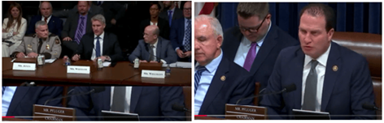

Homeland Security Republicans hearing, Dec 12, 2024

DRONES AND ORBS ARE HERE. THE GOVERNMENT DOES NOT KNOW WHAT TO DO OR SAY.

I’ve referred to a document called the [Lacerta Files](https://www.bibliotecapleyades.net/vida_alien/esp_vida_alien_52.htm) in previous [posts](https://open.substack.com/pub/stephenvance/p/everything-mostly-you-need-to-know?utm_campaign=post&utm_medium=web). The Lacerta Files is an interview with a physical being who claims to be native of Earth but is reptiloid with mammalian characteristics. They, the Terrans, predate humans by millions of years. Lacerta’s telling of their origins and human origins may shock the hell out of you. You may call fictional bull shit on it but there are too many connections there to ignore. Her telling of a long pre-human history of this planet and of other alien races and their interactions in the universe is fascinating or again, complete fiction if you believe humans are the apex of the universe. She was OK’d by her people to speak of these things as they knew then that almost no one would believe it. According to her, she was conducting research. Many of our assumptions of natural history, the history of humanity, including religion are challenged and refuted. Our understanding of science is seen as essentially infantile as we are just getting started. It seems a bit frustrating for her to get beyond our apex arrogance complex and she points out that the Terrans are no where near the apex of cognizant beings themselves. There are other aspects about our culture that she seems to despise mostly that we keep reverting to old ways of thinking like a kids blanket, but she personally has no ill will towards us. Some extraterrestrial aliens do though, or at least view us like ants.

A PREDICTED ALIEN WAR TO BE FOUGHT ON EARTH AND IN SPACE

She called this out in 2000. See page 20 of the Lacerta Files. She said that two alien races with interactions on earth had been engaged in something like a cold war amongst themselves for about 72 years. The assumption is that this cold war conflict involves resources on earth and humans as a resource. She had heard of a rumor that this cold war would erupt into a hot war in about 10 - 20 or so years and that it would be fought on earth and in space near earth. We are now witnessing the beginning of this war. According to Lacerta, this is absolutely not the first alien war to be fought here. I’d guess a real undeniable escalation is coming soon. I think that our governments are shitting their pants about now particularly that so much has been hidden from us for so many years. Disclosure needs to happen right now. The feds don’t know what to do but all you have to do is look up. Trust your own lying eyes or not. And hope something isn’t sprayed into them.